# Blogging with R

Tuesday March 26th, 2019

## Quick links

slides in htlm version

online link to [these slides](https://brdauria.github.io/codingclubuc3m_talk)

link to the slides’ [GitHub repository](https://github.com/brdauria/codingclubuc3m_talk)

link to the example [GitHub repository](https://github.com/brdauria/codingclubuc3m_talk_blog)

## What is a Blog?

### Definition of blog

A blog (shortening of **weblog**) is an online journal or informational website displaying information in the reverse chronological order, with latest posts appearing first.

It is a platform where a writer or even a group of writers share their views on an individual subject.

### Famous blog platforms:

[WordPress.org](http://wordpress.org/), [Ghost](https://ghost.org/), [Drupal](http://www.drupal.org/), [Joomla](https://www.joomla.org/), [Wordpress.com](http://wordpress.com/), [Medium](http://medium.com/), [Squarespace](https://www.squarespace.com/), [Weebly](https://www.weebly.com/), [Typepad](http://www.typepad.com/), [Blogger](https://www.blogger.com/), [Tumblr](http://tumblr.com/) and [Wix](https://www.wix.com/)

<sub>[source (2019)](https://makeawebsitehub.com/choose-right-blogging-platform/)</sub>

## The requisites of our blog

Out aim is to crate a simple blog by the following collection of tools:

- [R](https://www.r-project.org/) + [R Markdown](https://rmarkdown.rstudio.com/lesson-1.html)
- [RStudio](https://www.rstudio.com/) + [blogdown](https://bookdown.org/yihui/blogdown/)
- [git](https://git-scm.com/downloads) + [GitHub](https://github.com/)
- [Jekyll](https://jekyllrb.com/) + [GitHub Pages](https://pages.github.com/)

This will allow us to:

- **do not** need a personal web server
- easily include **formulas** and **statistical plot**  
  in our blog posts.

## R Markdown

**R Markdown** is a file format to make dynamic documents in **R**.

An R Markdown document is written in  
**markdown** (an easy-to-write plain text format)  
and contains chunks of **embedded R code**.

### Example:

````markdown
    # Plotting a simple Histogram

    We generate a number `n=50` of
    **Normal** disributed random variables
    and plot them as an histogram

    ```{r}
     hist(rnorm(50))
    ```
````

## Plotting a simple Histogram

We generate a number `n=50` of **Normal** disributed random variables and plot them as an histogram

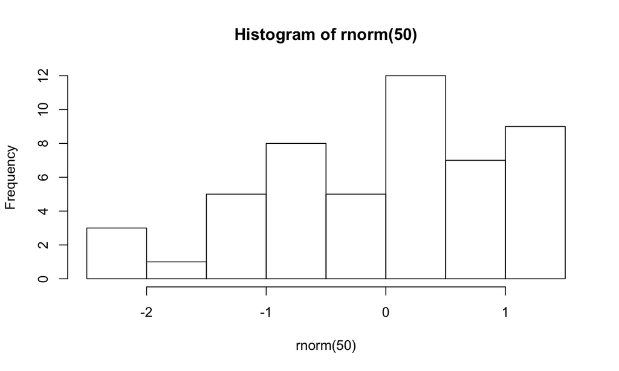

## blogdown + RStudio

`blogdown` is a package in R, developed by *Yihui Xie* (also author of `knitr`), that facilitates to build blogs with **R Markdown** in RStudio.

It is mainly tailored for the static generator **Hugo**, but following the author of the package, we tweak it to make it work with the static generator **Jekyll**.

### Book published on 2017:

[“blogdown: Creating Websites with R Markdown”](https://www.crcpress.com/blogdown-Creating-Websites-with-R-Markdown/Xie-Hill-Thomas/p/book/9780815363729)  
by Y. Xie, A. P. Hill, A. Thomas

it is also available [on-line](https://bookdown.org/yihui/blogdown/)

## git + GitHub

- Create a repository, for example name it `my_blog`,  
  and **initialize** it with a `README.md`
- Go to `Settings -> GitHub Pages`
  - set **Source** to **master branch**
  - select a **Jekyll theme**, for example to **Minimal**
- Edit your repository in the **main** page  
  and set its **website link**

To manipulate locally repositories from your coputer, you need to download and istall [git](https://git-scm.com/book/en/v2/Getting-Started-Installing-Git).

- [Linux](https://git-scm.com/download/linux)
- [Mac](http://git-scm.com/download/mac%22)
- [Windows](https://gitforwindows.org/)

## Associate RStudio with Github

- Then enable version control in RStudio by going to  
  `Tools -> Global Options... -> Git/SVN`
- There write the location of the `git` executable
- Then `Create RSA key...` or select one if you already have them.
- Then open the **Terminal** by going to  
  `Tools -> Shell...`
- and enter your details for your commits

  ```bash
  git config --global user.email "my.email@university.edu"
  git config --global user.name "my.username"
  ```

## Create a new RStudio project

- `File -> New Project... -> Version Control -> Git`
- Type the `url` of your GitHub repository
- Select a name and a location for your RStudio project

Then

- assure to have the package `blogdown` installed

  ```r
  ## Install from CRAN
  install.packages("blogdown")
  ## Or, install from GitHub
  if (!requireNamespace("devtools")) install.packages("devtools")
  devtools::install_github("brdauria/blogdown")
  ```

## Configure for Jekyll on GitHub Pages

- Set the file content [`_config.yml`](https://raw.githubusercontent.com/brdauria/codingclubuc3m_talk/master/docs/files/_config-v1.yml) as follows

  ```yaml
  title: My first blog
  description: >- # this means to ignore newlines until "email:"
    "This blog has been creatged during the mini-course
    'Blogging with R' by Bernardo D'Auria on Tue March 26th, 2019"
  email: my.email@university.edu

  # Build settings
  markdown: kramdown
  exclude: ['*.Rmd'] # this is important to use with RMarkdown
  theme: minima
  plugins:
    - jekyll-feed # to serve posts
  ```

- Create the folder `_posts`

## Configure for Jekyll on GitHub Pages

- Create the file [`Gemfile`](https://raw.githubusercontent.com/brdauria/codingclubuc3m_talk/master/docs/files/Gemfile-v1)

  ```yaml
  source "https://rubygems.org"

  # To upgrade, run `bundle update github-pages`.
  gem "github-pages", group: :jekyll_plugins

  group :jekyll_plugins do
    gem "jekyll-feed"
  end
  ```

- Add to [`.gitignore`](https://raw.githubusercontent.com/brdauria/codingclubuc3m_talk/master/docs/files/.gitignore-v1)

  ```bash
  _site/
  .sass-cache/
  .jekyll-cache/
  .jekyll-metadata
  ```

## Add an `index.html` page

- Create the file [`index.Rmd`](https://raw.githubusercontent.com/brdauria/codingclubuc3m_talk/master/docs/files/index-v1.Rmd)

  ````markdown
     ---
      layout: home
      title: "Welcome to my Blog"
     ---

      ```{r, echo=FALSE}
      library(ggplot2)

      ## Plot
      g <- ggplot(mpg, aes(cty))
      g + geom_density(aes(fill=factor(cyl)), alpha=0.8) +
          labs(title="Density plot", caption="Source: mpg",
               x="City Mileage", fill="# Cylinders")
      ```
  ````

- Run `knitr::knit('index.Rmd')`

## Make your FIRST post

- Create the file `_posts/`[`2019-03-01-HelloWorld.Rmd`](https://raw.githubusercontent.com/brdauria/codingclubuc3m_talk/master/docs/files/_posts/2019-03-01-HelloWorld.Rmd)

  ````markdown
      ---
      title: "Hello World!"
      author: "Bernardo D'Auria"
      date: "2019-03-01"
      ---
      Let us sum `1+1` by **R**.

      ```{r}
      1+1
      ```
  ````

- Run

  ```r
    owd = setwd('_posts/');
    knitr::knit('2019-03-01-HelloWorld.Rmd'); setwd(owd);
  ```

## The blog works!

- `Commit` and `Push`

Now going to the url of the **GitHub Pages** of our repository,

the blog WORKS!

### To run it locally:

You need to have **Jekyll** installed

- run `bundle install`
- run `bundle exec jekyll serve`
- open in the browser the url `http://127.0.0.1:4000/`

## Jekyll

`Jekyll` is a simple, blog-aware, static site generator perfect for personal, project, or organization sites.

Jekyll is the engine behind GitHub Pages, which you can use to host sites right from your GitHub repositories.

- find [here](https://jekyllrb.com/docs/installation/) the instructions to install for different platforms
- it may require to download and install a more recent version of [Ruby language](https://www.ruby-lang.org/en/downloads/)
- assure to have run the command

  ```bash
  bundle install
  ```

- Example in class:  
  run `jekyll new . --force` in the project folder

## Make Jekyll the generator for blogdown

- create the hidden file [`.Rprofile`](https://raw.githubusercontent.com/brdauria/codingclubuc3m_talk/master/docs/files/.Rprofile) in the project directory

  ```bash
  options(
     blogdown.generator = 'jekyll', blogdown.method = 'custom',
     blogdown.subdir = '_posts', servr.daemon = TRUE,
     blogdown.base.dir = 'assets/figures/',
     blogdown.base.url = '{{ "assets/figures/" | absolute_url }}'
   )
   # IMPORTANT: please leave this comment line!
  ```

## Make Jekyll the generator for blogdown

- create a new folder, name it `R`, containing two files:  
  - [`build.R`](https://raw.githubusercontent.com/brdauria/codingclubuc3m_talk/master/docs/files/R/build.R)  
  - [`build_one.R`](https://raw.githubusercontent.com/brdauria/codingclubuc3m_talk/master/docs/files/R/build_one.R)

  You can download them by clicking on them  
  or you can look for them in the `R` directory in the brdauria/blogdown-jekyll repository
- make `sw/hd` link `config.yaml` to `_config.yml`

  ```bash
  ln -s _config.yml config.yaml # on MAC/Linux
  mklink config.yaml _config.yml # on Windows
  ```

## Make your SECOND post

- Select in the toolbar `Addins -> New Post`
- Type the following informations

  ```yaml
  Title:    "Hello Jekyll!"
  Author:   "Bernardo D'Auria"
  Date:     2019-03-05
  Category: graphs
  Format:   R Markdown (.Rmd)
  ```

- Click on `Done`

A new file named `2019-03-05-hello-jekyll.Rmd`  
will be added in the `_posts` directory  
and it will be opened for modifications.

## Make your SECOND post

- Modify the YAML header of the post as follows

  ```yaml
  ---
  title: Hello Jekyll!
  author: "Bernardo D'Auria"
  date: '2019-03-05'
  slug: hello-jekyll
  categories:
    - graphs
  tags: []

  layout: post
  ---
  ```

## Make your SECOND post

- and the body as the following

  ````r
  This is my first plot that cointains an R graph

  ```{r}
  library(ggplot2)
  ggplot(iris,aes(x=Sepal.Width,y=Sepal.Length)) + geom_point()
  ```

  and an external picture

  ![colored cats](https://raw.githubusercontent.com/brdauria/codingclubuc3m_talk/master/docs/images/cats.jpg)

  ```
  ````

you can download the file here 2019-03-05-hello-jekyll.Rmd

## Make your SECOND post

- `build` and `serve` your blog  
  `Addins -> Serve Site`

  and in the `Viewer Pane`  
  you should see your blog

  WORKING with PICTURES!
- `commit` and `push`

  and you should see your blog also in

  WORKING in INTERNET!

## Needing some formulas

What we finally miss is to include in our posts some  
nice formulas

- like this \(\sqrt{\frac{9}{4}} = \frac{3}{2}\)
- and this

  \[ \int_0^{\infty} e^{-x^2} dx = \frac{\sqrt{\pi}}{2} \]

So let us prepare our blog and make our **third post**!

## Jekyll directory structure

```
.
├── _config.yml
├── _data
|   └── members.yml
├── _drafts
|   ├── begin-with-the-crazy-ideas.md
|   └── on-simplicity-in-technology.md
├── _includes
|   ├── footer.html
|   └── header.html
├── _layouts
|   ├── default.html
|   └── post.html
├── _posts
|   ├── 2007-10-29-post-2.md
|   └── 2009-04-26-post-1.md
├── _sass
|   ├── _base.scss
|   └── _layout.scss
├── _site # generated by jekyll and containing the website
├── .jekyll-metadata
├── Gemfile
├── Gemfile.lock
└── index.html # can also be an 'index.md' with valid front matter
```

## The theme `minima` directory structure

- run the command

  ```r
  system2('bundle', 'show minima')
  ```

  to get the `minima` gem location.
- then

  ```r
  list.files('/usr/local/lib/ruby/gems/2.5.0/gems/minima-2.5.0')
  ```

## The theme `minima` directory structure

```
/usr/local/lib/ruby/gems/2.5.0/gems/minima-2.5.0
├── _includes
|   ├── disqus_comments.html
|   ├── footer.html
|   ├── google-analytics.html
|   ├── head.html
|   ├── header.html
|   ├── icon-github.html
|   ├── icon-github.svg
|   ├── icon-twitter.html
|   ├── icon-twitter.svg
|   └── social.html
├── _layouts
|   ├── default.html
|   ├── home.html
|   ├── page.html
|   └── post.html
├── _sass
|   ├── minima
|   |   └── ...
|   └── minima.scss
├── assets
|   ├── main.scss
|   └── minima-social-icons.svg
├── LICENSE.txt
└── README.md
```

## Customize the blog to allow formulas

- in the folder `_includes` create [`mathjax.html`](https://raw.githubusercontent.com/brdauria/codingclubuc3m_talk/master/docs/files/_includes/mathjax.html)

  ```html
  {% if layout.mathjax or page.mathjax %}
  <!-- https://docs.mathjax.org/en/
              latest/configuration.html#local-config-files -->
  <script type="text/javascript"
          src="https://cdnjs.cloudflare.com/ajax/libs/mathjax/2.7.4/
               latest.js?config=TeX-AMS-MML_HTMLorMML,
               {{ 'assets/js/MathJaxLocal.js' | absolute_url }}">
  </script>
  {% endif %}
  ```

  It contains **Liquid templating** syntax! See [here](https://jekyllrb.com/docs/liquid/) for more!
- in the folder `assets/js` create [`MathJaxLocal.js`](https://raw.githubusercontent.com/brdauria/codingclubuc3m_talk/master/docs/files/assets/js/MathJaxLocal.js)

  ```
  # TOO BIG to include here. Please click to download!
  ```

## Customize the blog to allow formulas

- in the folder `_layouts` create [`mpost.html`](https://raw.githubusercontent.com/brdauria/codingclubuc3m_talk/master/docs/files/_layouts/mpost.html)

  ```html
  ---
  layout: post
  mathjax: true
  ---

  {% include mathjax.html %}

  {{ content }}
  ```

## Make your THIRD post

- Select in the toolbar `Addins -> New Post`
- Type the following informations

  ```yaml
  Title:    "Hello Math!"
  Author:   "Bernardo D'Auria"
  Date:     2019-03-15
  Category: math
  Format:   R Markdown (.Rmd)
  ```

- Click on `Done`

A new file named `2019-03-15-hello-math.Rmd`  
will be added in the `_posts` directory  
and it will be opened for modifications.

## Make your THIRD post

- Modify the YAML header of the post as follows

  ```yaml
  ---
  title: Hello Math!
  author: "Bernardo D'Auria"
  date: '2019-03-15'
  slug: hello-math
  categories:
    - math
  tags: []

  layout: mpost
  ---
  ```

## Make your THIRD post

- and the body as the following

  ```markdown
  This is my first plot that cointains
  nice formulas

  - like this
  \\( \sqrt{\frac{9}{4}} = \frac{3}{2} \\)

  - and this

    $$ \int_0^{\infty} e^{-x^2} dx = \frac{\sqrt{\pi}}{2} $$
  ```

you can download the file here 2019-03-15-hello-math.Rmd

- see immediatelt the preview in the **Viewer Pane**
- `commit` and `push` to check it in Internet

## Working with Themes

**Jekyll** is very powerful for

- its modularity
- its themes

However this has a *cost*:

- **things may work slightly different from *theme* to *theme***

therefore there is some **extra work** to do!

We are going to work with: [Minimal Mistakes](https://mmistakes.github.io/minimal-mistakes/) theme

## Minimal Mistakes theme

- remove `index.md` and write [`index.html`](https://raw.githubusercontent.com/brdauria/codingclubuc3m_talk/master/docs/files/index-MinimalMistakes.html) as follows:

  ```yaml
     ---
      layout: home
      author_profile: true
     ---
  ```

- add to [`Gemfile`](https://raw.githubusercontent.com/brdauria/codingclubuc3m_talk/master/docs/files/Gemfile-MinimalMistakes)

  ```yaml
     group :jekyll_plugins do
      ...
      gem "jekyll-include-cache"
    end
  ```

## Minimal Mistakes theme

- add to `_config.yml` this

  ```yaml
     github: [metadata] # important to use remote_theme
     minimal_mistakes_skin: dark
     remote_theme: "mmistakes/minimal-mistakes@4.15.2"
     paginate: 5
     plugins:
      ...
      - jekyll-include-cache
      - jekyll-paginate
  ```

## Minimal Mistakes theme

- add to [`_config.yml`](https://raw.githubusercontent.com/brdauria/codingclubuc3m_talk/master/docs/files/_config-MinimalMistakes.yml) and this

  ```yaml
      # Front Matter Defaults:
      defaults:
        # _posts
        - scope:
            path: ""
            type: posts
          values:
            layout: single
            author_profile: true
            read_time: true
            comments: true
            share: true
            related: true
  ```

- then `Commit` and `Push`

## More resources

**Jekyll**

- [docs](https://jekyllrb.com/docs/)
- [tutorials](https://jekyllrb.com/tutorials/home/)
- [themes](http://jekyllthemes.org/)

online books

- [R Mardown](https://bookdown.org/yihui/rmarkdown/): The Definitive Guide
- [blogdown](https://bookdown.org/yihui/blogdown/): Creating Websites with R Markdown

## Thanks

[**Coding Club**](https://codingclubuc3m.github.io) UC3M

[**tidyverse**](https://ggplot2.tidyverse.org) ecosystem

Slides created via [**R Mardown**](https://github.com/rstudio/rmarkdown) package and [**ioslides**](https://github.com/iosscripts/iosslider)

Blog created with [**Jekyll**](https://jekyllrb.com/)

Hosted in [**GitHub**](https://github.com/)

Using [*RStudio*](https://www.rstudio.com/) and [**blogdown**](https://bookdown.org/yihui/blogdown/) package

plus some tweaks of the *Yihui Xie*`s [**blogdown-jekyll**](https://github.com/yihui/blogdown-jekyll) repository